# Malignant Melanoma

Jonas Hughes Larsen

1/31/2021

## Demographics

| Dependent: Status |  | dead_melanoma | alive | dead_other | p |
| --- | --- | --- | --- | --- | --- |
| Sex | female | 28 (49.1) | 91 (67.9) | 7 (50.0) | 0.033 |
|  | male | 29 (50.9) | 43 (32.1) | 7 (50.0) |  |
| Age (years) | Mean (SD) | 55.1 (17.9) | 50.0 (15.9) | 65.3 (10.9) | 0.002 |
| Tumor thickness (mm) | Mean (SD) | 4.3 (3.6) | 2.2 (2.3) | 3.7 (3.6) | <0.001 |
| Ulcerated tumor | absent | 16 (28.1) | 92 (68.7) | 7 (50.0) | <0.001 |
|  | present | 41 (71.9) | 42 (31.3) | 7 (50.0) |  |

## Logistic Regression

Dependent: 5-year survival

No

Yes

OR (univariable)

OR (multivariable)

Ulcerated tumor

absent

105 (91.3)

10 (8.7)

present

55 (61.1)

35 (38.9)

6.68 (3.18-15.18, p<0.001)

3.21 (1.32-8.28, p=0.012)

Age (years)

Mean (SD)

51.7 (16.0)

55.3 (18.8)

1.01 (0.99-1.03, p=0.202)

1.00 (0.98-1.02, p=0.948)

Sex

female

105 (83.3)

21 (16.7)

male

55 (69.6)

24 (30.4)

2.18 (1.12-4.30, p=0.023)

1.26 (0.57-2.76, p=0.558)

T-stage

T1

52 (92.9)

4 (7.1)

T2

49 (92.5)

4 (7.5)

1.06 (0.24-4.71, p=0.936)

0.77 (0.16-3.58, p=0.733)

T3

36 (70.6)

15 (29.4)

5.42 (1.80-20.22, p=0.005)

2.98 (0.86-12.10, p=0.098)

T4

23 (51.1)

22 (48.9)

12.43 (4.21-46.26, p<0.001)

4.98 (1.34-21.64, p=0.021)

## Odds ratios

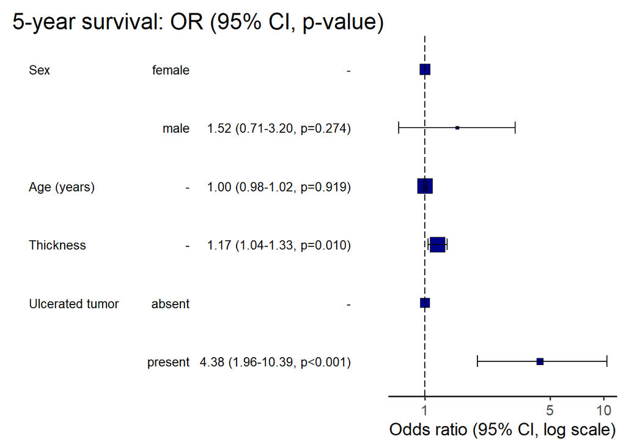

## Overall Survival

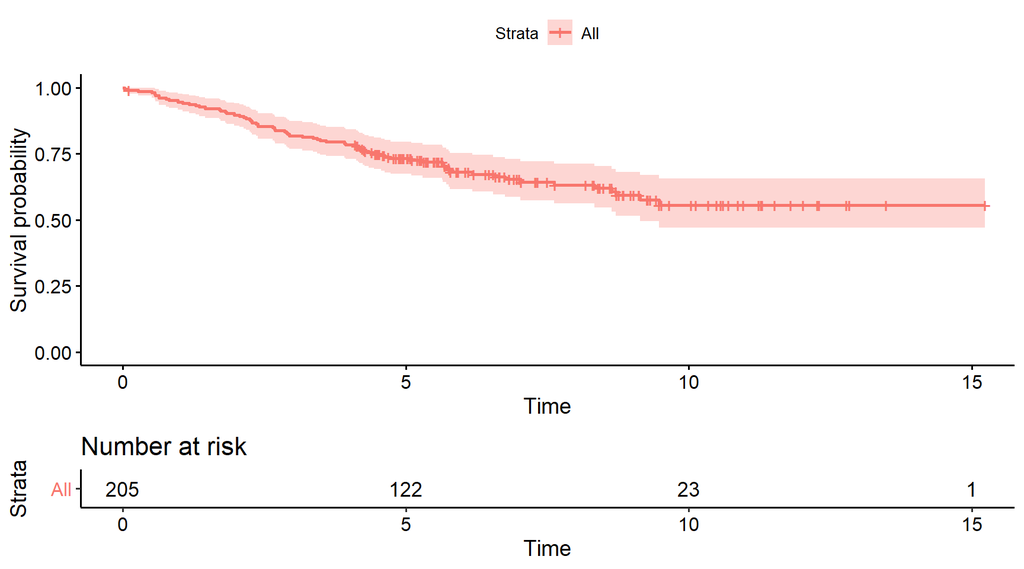

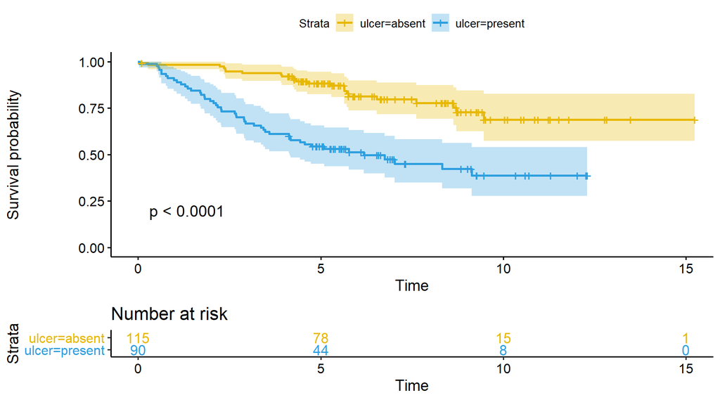

## Disease Specific Survival

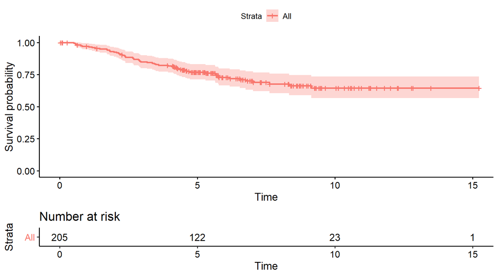

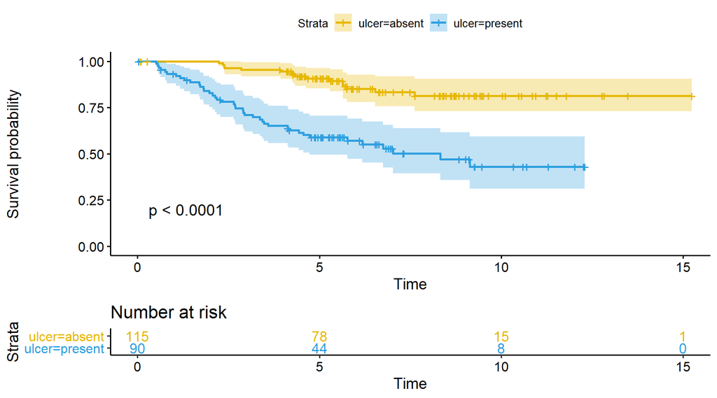

## Cox Proportional Hazard Model

Overall survival

HR (univariable)

HR (multivariable)

Age (years)

Mean (SD)

52.5 (16.7)

1.03 (1.01-1.05, p<0.001)

1.02 (1.01-1.04, p=0.005)

Sex

female

126 (100.0)

male

79 (100.0)

1.93 (1.21-3.07, p=0.006)

1.51 (0.94-2.42, p=0.085)

Thickness

Mean (SD)

2.9 (3.0)

1.16 (1.10-1.23, p<0.001)

1.10 (1.03-1.18, p=0.004)

Ulcerated tumor

absent

115 (100.0)

present

90 (100.0)

3.52 (2.14-5.80, p<0.001)

2.59 (1.53-4.38, p<0.001)

## Hazard ratios

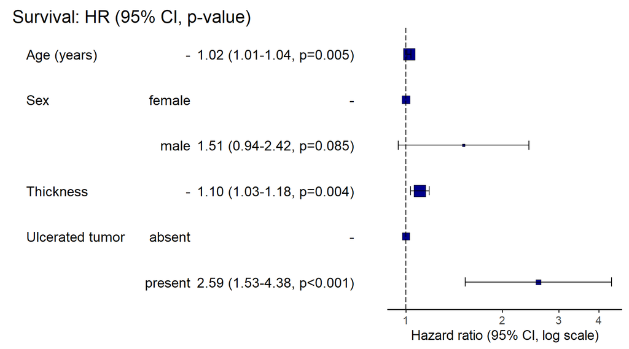

## Bootstrap confidence intervals using rsample package

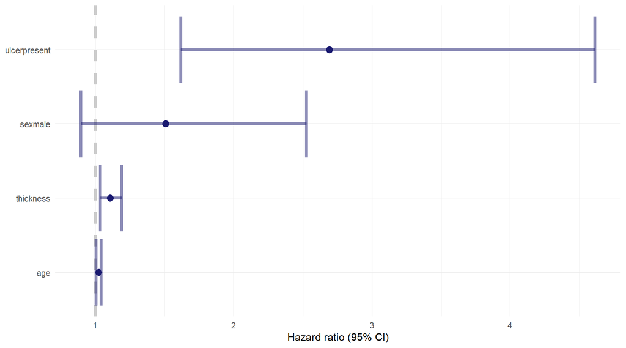

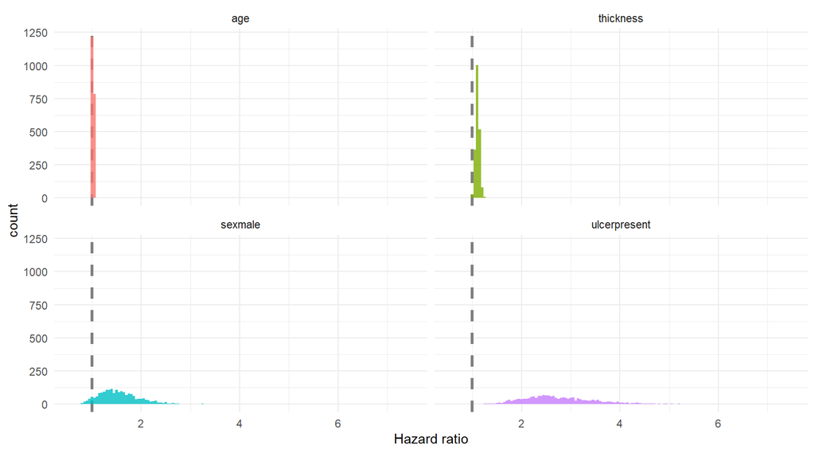

## Competing Risk

Dependent: Survival

all

HR (DSS CPH univariable)

HR (DSS CPH multivariable)

HR (competing risks multivariable)

Age (years)

Mean (SD)

52.5 (16.7)

1.01 (1.00-1.03, p=0.141)

1.01 (1.00-1.03, p=0.141)

1.01 (0.99-1.02, p=0.520)

Sex

female

126 (61.5)

male

79 (38.5)

1.54 (0.91-2.60, p=0.106)

1.54 (0.91-2.60, p=0.106)

1.50 (0.87-2.57, p=0.140)

Thickness

Mean (SD)

2.9 (3.0)

1.12 (1.04-1.20, p=0.004)

1.12 (1.04-1.20, p=0.004)

1.09 (1.01-1.18, p=0.019)

Ulcerated tumor

absent

115 (56.1)

present

90 (43.9)

3.20 (1.75-5.88, p<0.001)

3.20 (1.75-5.88, p<0.001)

3.09 (1.71-5.60, p<0.001)